# Pre2 - EDA

## 0.1 Use Case

Our tool targets the fire department and residents.

The Philadelphia Fire Department responds to hundreds or even thousands of locations everyday to quell an array of emergencies. Currently, they have no ‘situational awareness’ of fire risk for a given location when an emergency call comes in. Therefore, we are going to help them create such a tool, by providing a parcel-level (building) fire risk score prediction for each property in the City;

In addition, we want to let residents get a real-time update of the fire risk of their houses so they will have a situational awareness on risk for each property citywide.

## 0.2 Load Data

```r
library(tidyverse)
library(sf)
library(QuantPsyc)
library(RSocrata)
library(viridis)
library(caret)
library(spatstat)
library(spdep)
library(FNN)
library(grid)
library(gridExtra)
library(knitr)
library(kableExtra)
library(tidycensus)

library(mapview)
library(httr)
library(dplyr)
library(readxl)
library(stringr)

mapTheme <- function(base_size = 12) {
  theme(
    text = element_text( color = "black"),
    plot.title = element_text(size = 14,colour = "black"),
    plot.subtitle=element_text(face="italic"),
    plot.caption=element_text(hjust=0),
    axis.ticks = element_blank(),
    panel.background = element_blank(),axis.title = element_blank(),
    axis.text = element_blank(),
    axis.title.x = element_blank(),
    axis.title.y = element_blank(),
    panel.grid.minor = element_blank(),
    panel.border = element_rect(colour = "black", fill=NA, size=2)
  )
}

plotTheme <- function(base_size = 12) {
  theme(
    text = element_text( color = "black"),
    plot.title = element_text(size = 14,colour = "black"),
    plot.subtitle = element_text(face="italic"),
    plot.caption = element_text(hjust=0),
    axis.ticks = element_blank(),
    panel.background = element_blank(),
    panel.grid.major = element_line("grey80", size = 0.1),
    panel.grid.minor = element_blank(),
    panel.border = element_rect(colour = "black", fill=NA, size=2),
    strip.background = element_rect(fill = "grey80", color = "white"),
    strip.text = element_text(size=12),
    axis.title = element_text(size=12),
    axis.text = element_text(size=10),
    plot.background = element_blank(),
    legend.background = element_blank(),
    legend.title = element_text(colour = "black", face = "italic"),
    legend.text = element_text(colour = "black", face = "italic"),
    strip.text.x = element_text(size = 14)
  )
}

#Nearest neighbor (NND) function
nn_function <- function(measureFrom,measureTo,k) {
  measureFrom_Matrix <- as.matrix(measureFrom)
  measureTo_Matrix <- as.matrix(measureTo)
  nn <-
    get.knnx(measureTo, measureFrom, k)$nn.dist
    output <-
      as.data.frame(nn) %>%
      rownames_to_column(var = "thisPoint") %>%
      gather(points, point_distance, V1:ncol(.)) %>%
      arrange(as.numeric(thisPoint)) %>%
      group_by(thisPoint) %>%
      summarize(pointDistance = mean(point_distance)) %>%
      arrange(as.numeric(thisPoint)) %>%
      dplyr::select(-thisPoint) %>%
      pull()

  return(output)
}
```

```r
fire <- read_excel("./data/fire.xlsx")
property <- read_csv("./data/opa_properties_public.csv")
parcel <- read_csv("./data/DOR_Parcel.csv")
opa <- read_csv("./data/Fire_OPA_Parcel.csv")
```

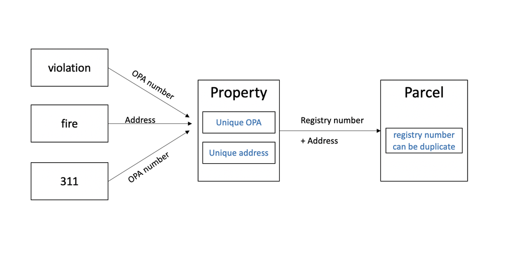

relation

```r
fire1 = fire %>%
  filter(addr_type ==1)
fire1$address <- paste(ifelse(is.na(fire1$number)==FALSE,fire1$number,''),
                       "%20",
                       ifelse(is.na(fire1$st_prefix)==FALSE,fire1$st_prefix,''),
                       "%20",
                       ifelse(is.na(fire1$street)==FALSE,fire1$street,''),
                       "%20",
                       ifelse(is.na(fire1$st_type)==FALSE,fire1$st_type,''), sep = "")
fire2 = fire %>%
  filter(addr_type ==2)
fire2$address <- paste(ifelse(is.na(fire2$xst_prefix)==FALSE,fire2$xst_prefix,''),
                       ifelse(fire2$xst_prefix!='',"%20",''),
                       ifelse(is.na(fire2$xstreet)==FALSE,fire2$xstreet,''),
                       "%20",
                       ifelse(is.na(fire2$xst_type)==FALSE,fire2$xst_type,''),
                       "%20",
                       "&",
                       "%20",
                       ifelse(is.na(fire2$st_prefix)==FALSE,fire2$st_prefix,''),
                       ifelse(fire2$st_prefix!='',"%20",''),
                       ifelse(is.na(fire2$street)==FALSE,fire2$street,''),
                       "%20",
                       ifelse(is.na(fire2$st_type)==FALSE,fire2$st_type,''),
                       sep = "")
fireData <- rbind(fire1, fire2)

fireData$MUSA_ID <- paste0("MUSA_",1:nrow(fireData))
```

```r
fire_opa <- left_join(fireData,opa,by='MUSA_ID')

property <- rename(property, OPA_Num = parcel_number)
property_fire <- left_join(property,fire_opa,by='OPA_Num')
parcel <- rename(parcel, registry_number = BASEREG)
parcel_pro_fire <- left_join(parcel,property_fire,by='registry_number')
parcel_pro_fire = parcel_pro_fire %>%filter(ADDR_STD==location)
```

```r
limit <-
  st_read("./data/City_Limits-shp/city_limits.shp") %>%
  st_transform(2272)
```

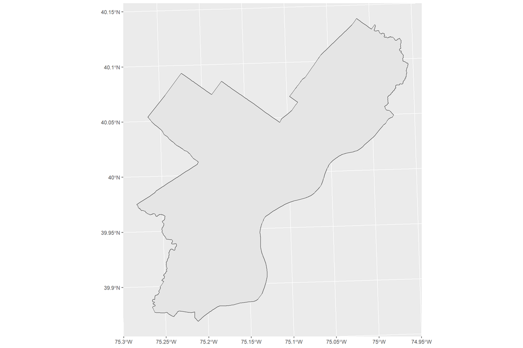

```r
ggplot() +
  geom_sf(data = limit)
```

```r
tracts <-
  st_read("http://data.phl.opendata.arcgis.com/datasets/ccdc0d022f4949a7b11333bd37231aef_0.geojson")%>%
  st_set_crs(4326) %>%
  na.omit() %>%
  st_transform(crs=2272)
neighborhoods <-
  st_read("https://raw.githubusercontent.com/azavea/geo-data/master/Neighborhoods_Philadelphia/Neighborhoods_Philadelphia.geojson")%>%
  st_set_crs(4326) %>%
  na.omit() %>%
  st_transform(crs=2272)
dor <-
  st_read("./data/DOR_Parcel/DOR_Parcel.shp")
```

## 0.3 EDA

```r
# load the fire data
colnames(parcel_pro_fire)
```

```
##   [1] "OBJECTID"                  "RECSUB"
##   [3] "registry_number"           "MAPREG"
##   [5] "PARCEL"                    "RECMAP"
##   [7] "STCOD"                     "HOUSE"
##   [9] "SUF"                       "UNIT"
##  [11] "STEX"                      "STDIR"
##  [13] "STNAM"                     "STDESSUF"
##  [15] "ELEV_FLAG"                 "TOPELEV"
##  [17] "BOTELEV"                   "CONDOFLAG"
##  [19] "MATCHFLAG"                 "INACTDATE"
##  [21] "ORIG_DATE"                 "STATUS"
##  [23] "GEOID"                     "STDES"
##  [25] "ADDR_SOURCE"               "ADDR_STD"
##  [27] "COMMENTS"                  "PIN"
##  [29] "FRAC"                      "UNIT_TYPE"
```

[output cut: 58 more lines]

```r
coords = st_centroid(dor)

parcel.sf <-
  st_as_sf(coords, crs = 4326) %>%
  st_transform(2272)

parcel.sf <- rename(parcel.sf, registry_number = BASEREG)
parcel.sf2 <- left_join(parcel.sf,property_fire,by='registry_number')
parcel.sf2 = parcel.sf2 %>%filter(ADDR_STD==location)
```

### 0.3.1 Previous Fire

The first risk factor is the spatial correlation of fire incidents. To understand if fires have a tendency to cluster in Philadelphia, we examined the average distance to 5 nearest fire event for each parcel. The results indicate that buildings with a smaller distance to past fires have a higher risk for future fire event.

```r
library(lubridate)

fire.sf <-
  parcel.sf2 %>%
  mutate(date=dmy(alm_date),
         Year=year(date),
         Month=month(date))

fire.sf_19 <- fire.sf[fire.sf$Year==2019,]
fire.sf_192 <- fire.sf_19[!is.na(fire.sf_19$Year),]

fire.sf_18 <- fire.sf[fire.sf$Year==2018,]
fire.sf_182 <- fire.sf_18[!is.na(fire.sf_18$Year),]

#fire.sf_17 <- fire.sf[fire.sf$Year==2017,]
#fire.sf_172 <- fire.sf_18[!is.na(fire.sf_17$Year),]

#fire.sf_16 <- fire.sf[fire.sf$Year==2016,]
#fire.sf_162 <- fire.sf_18[!is.na(fire.sf_16$Year),]

#fire.sf_15 <- fire.sf[fire.sf$Year==2015,]
#fire.sf_152 <- fire.sf_18[!is.na(fire.sf_15$Year),]
```

```r
# the distance from the nearest 5 fires to the center of the grid for each year(2015-2018)
parcel.sf2$lagfire19.nn5 <-nn_function(st_coordinates(parcel.sf2),st_coordinates(fire.sf_192),5)
parcel.sf2$lagfire18.nn5 <-nn_function(st_coordinates(parcel.sf2),st_coordinates(fire.sf_182),5)
#fire.sf$lagfire17.nn5 <-nn_function(st_coordinates(fire.sf),st_coordinates(fire.sf_172),5)
#fire.sf$lagfire16.nn5 <-nn_function(st_coordinates(fire.sf),st_coordinates(fire.sf_162),5)
#fire.sf$lagfire15.nn5 <-nn_function(st_coordinates(fire.sf),st_coordinates(fire.sf_152),5)
```

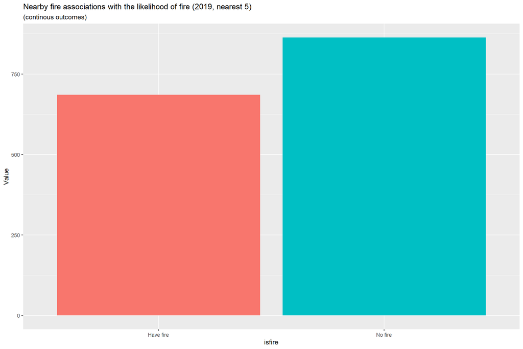

```r
fire_property_trim <-mutate(parcel.sf2, isfire = case_when(
  is.na(inci_no) == FALSE  ~ "Have fire",
  is.na(inci_no) == TRUE  ~ "No fire"))

fire_property_trim %>%
    ggplot(aes(isfire, lagfire19.nn5, fill=isfire)) +
      geom_bar(position = "dodge", stat = "summary", fun.y = "mean") +
      #scale_fill_manual(values = palette2) +
      labs(x="isfire", y="Value",
           title = "Nearby fire associations with the likelihood of fire (2019, nearest 5)",
           subtitle = "(continous outcomes)") +
      theme(legend.position = "none")
```

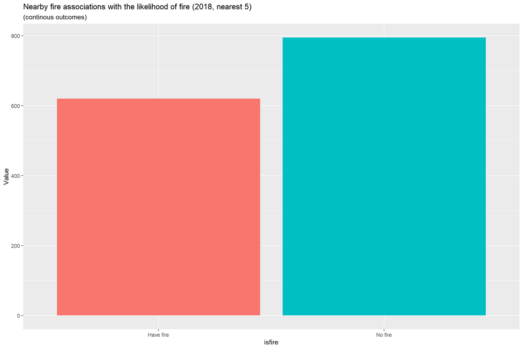

```r
fire_property_trim %>%
    ggplot(aes(isfire, lagfire18.nn5, fill=isfire)) +
      geom_bar(position = "dodge", stat = "summary", fun.y = "mean") +
      #scale_fill_manual(values = palette2) +
      labs(x="isfire", y="Value",
           title = "Nearby fire associations with the likelihood of fire (2018, nearest 5)",
           subtitle = "(continous outcomes)") +
      theme(legend.position = "none")
```

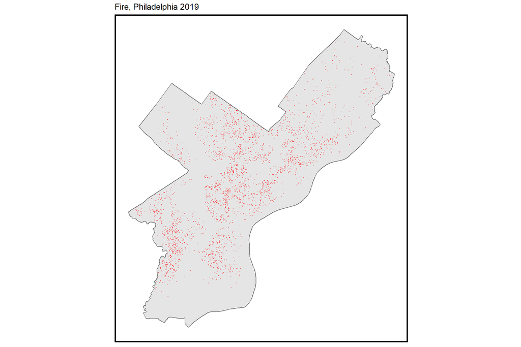

```r
ggplot() +
  geom_sf(data = limit) +
  geom_sf(data = fire.sf_192, colour="red", size=0.1, show.legend = "point") +
  labs(title= "Fire, Philadelphia 2019") +
  mapTheme()
```

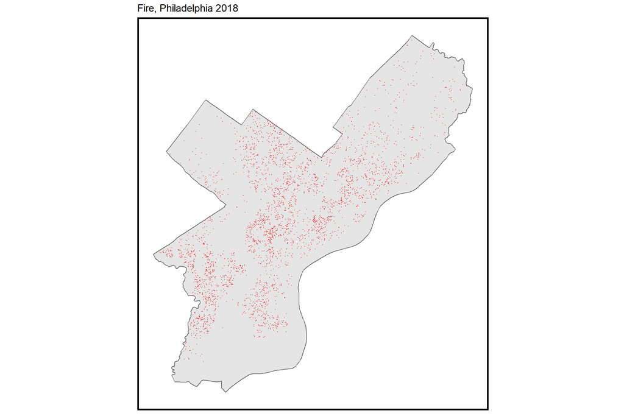

```r
ggplot() +
  geom_sf(data = limit) +
  geom_sf(data = fire.sf_182, colour="red", size=0.1, show.legend = "point") +
  labs(title= "Fire, Philadelphia 2018") +
  mapTheme()
```

### 0.3.2 Neighborhood Story

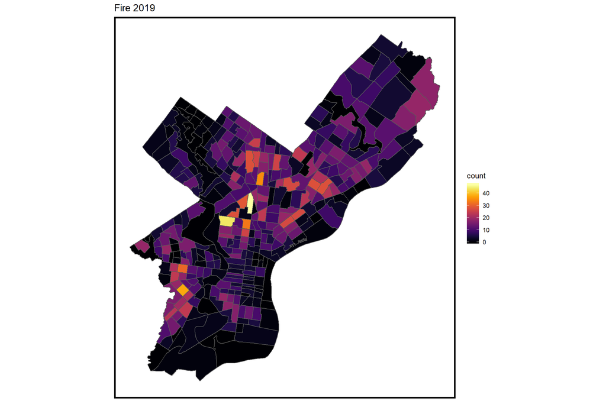

```r
fire_tracts <-
  fire.sf_192 %>%
  dplyr::select() %>%
  mutate(count = 1) %>%
  aggregate(., tracts, sum) %>%
  mutate(count = ifelse(is.na(count), 0, count),
         uniqueID = rownames(.),
         cvID = sample(round(nrow(tracts) / 24), size=nrow(tracts), replace = TRUE))

ggplot() +
  geom_sf(data = fire_tracts, aes(fill = count)) +
  scale_fill_viridis(option='inferno') +
  labs(title = "Fire 2019") +
  mapTheme()
```

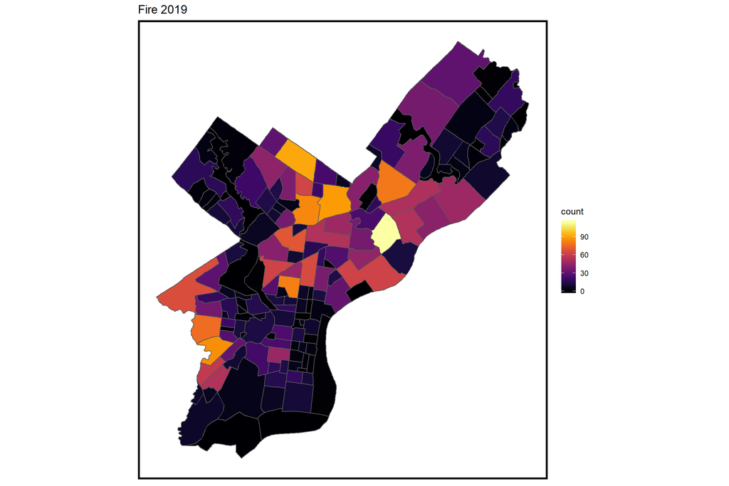

```r
fire_neighborhoods <-
  fire.sf_192 %>%
  dplyr::select() %>%
  mutate(count = 1) %>%
  aggregate(., neighborhoods, sum) %>%
  mutate(count = ifelse(is.na(count), 0, count),
         uniqueID = rownames(.),
         cvID = sample(round(nrow(neighborhoods) / 24), size=nrow(neighborhoods), replace = TRUE))

ggplot() +
  geom_sf(data = fire_neighborhoods, aes(fill = count)) +
  scale_fill_viridis(option='inferno') +
  labs(title = "Fire 2019") +
  mapTheme()
```

### 0.3.3 Building Features & Code violation

We looked into all the properties in philadelphia to examine whether there is a higher percentage of fire occurrence in the properties with certain features.

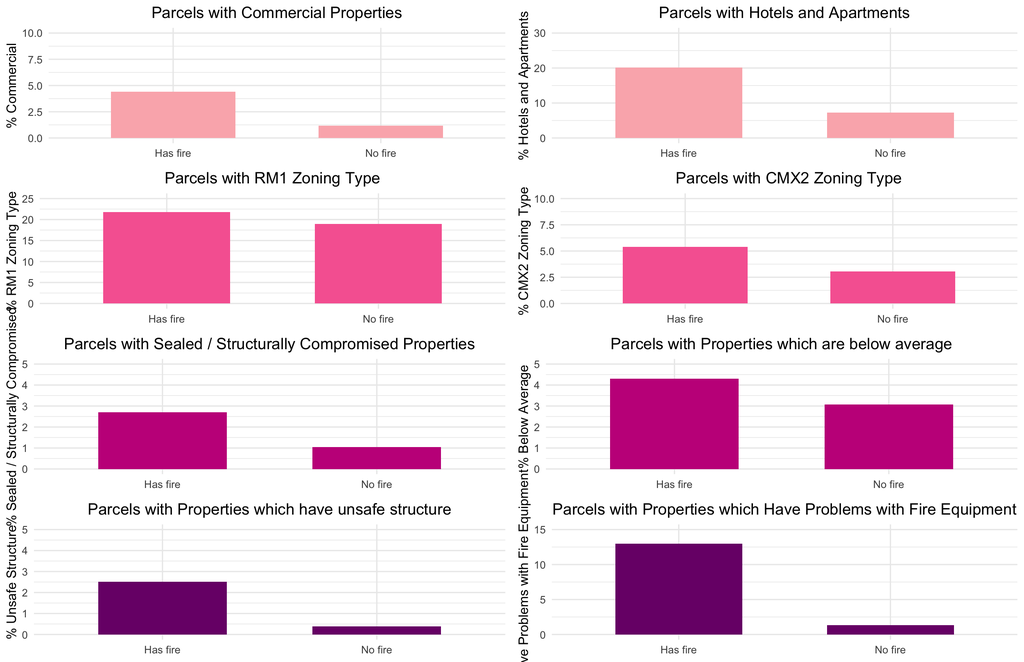

Building features & violation

As to property category, there is a higher percentage of fire occurrence in commercial, hotels and apartments properties.

Slightly more fire occurred in the properties which are sealed or structurally compromised.

### 0.3.4 311 Request

```r
request <- read_csv("./data/public_cases_fc2019.csv") %>%
  drop_na(lat)

request.sf    <- request %>%
  st_as_sf(coords = c("lon", "lat"), crs = 4326) %>%
  st_transform(2272)
```

```r
parcel.sf2$request19.nn5 <-nn_function(st_coordinates(parcel.sf2),st_coordinates(request.sf),5)
```

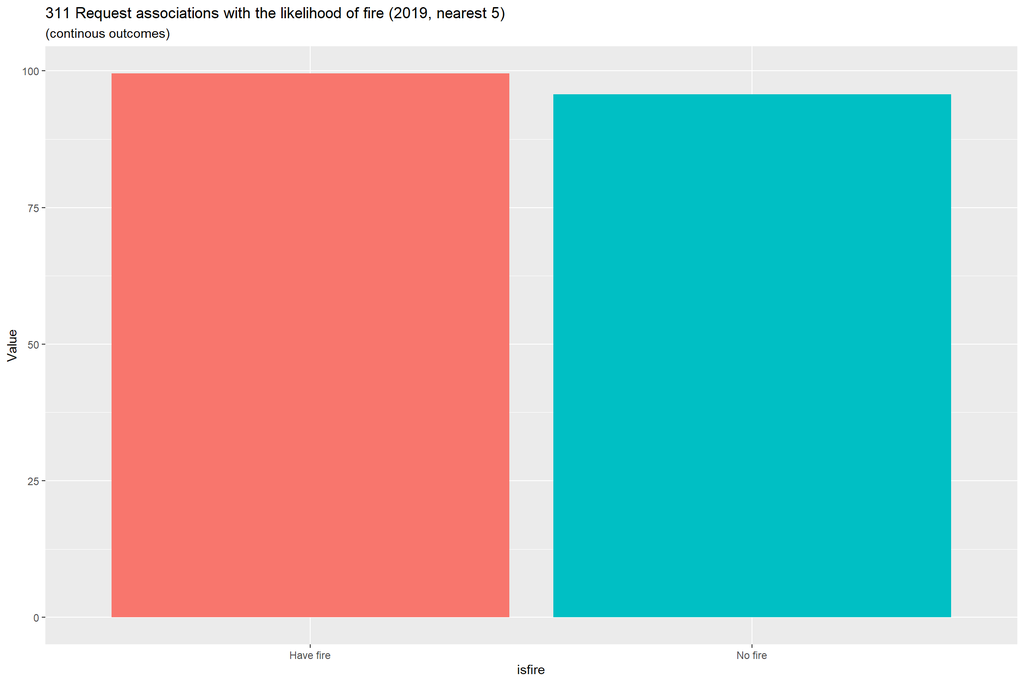

```r
fire_property_trim <-mutate(parcel.sf2, isfire = case_when(
  is.na(inci_no) == FALSE  ~ "Have fire",
  is.na(inci_no) == TRUE  ~ "No fire"))

fire_property_trim %>%
    ggplot(aes(isfire, request19.nn5, fill=isfire)) +
      geom_bar(position = "dodge", stat = "summary", fun.y = "mean") +
      #scale_fill_manual(values = palette2) +
      labs(x="isfire", y="Value",
           title = "311 Request associations with the likelihood of fire (2019, nearest 5)",
           subtitle = "(continous outcomes)") +
      theme(legend.position = "none")
```

```r
request.sf2    <- request.sf %>% filter(request.sf$service_name == 'Illegal Dumping' )
```

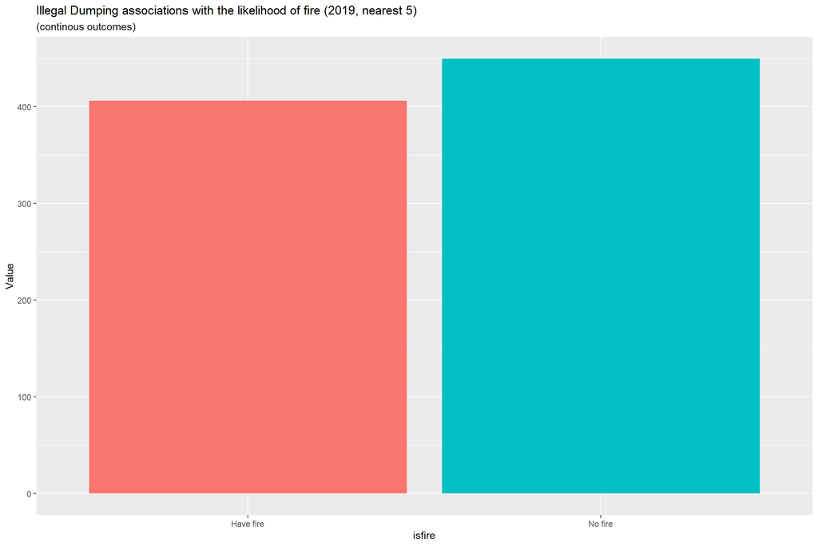

```r
fire_property_trim$dumping.nn5 <-nn_function(st_coordinates(fire_property_trim),st_coordinates(request.sf2),5)

fire_property_trim %>%
    ggplot(aes(isfire, dumping.nn5, fill=isfire)) +
      geom_bar(position = "dodge", stat = "summary", fun.y = "mean") +
      #scale_fill_manual(values = palette2) +
      labs(x="isfire", y="Value",
           title = "Illegal Dumping associations with the likelihood of fire (2019, nearest 5)",
           subtitle = "(continous outcomes)") +
      theme(legend.position = "none")
```

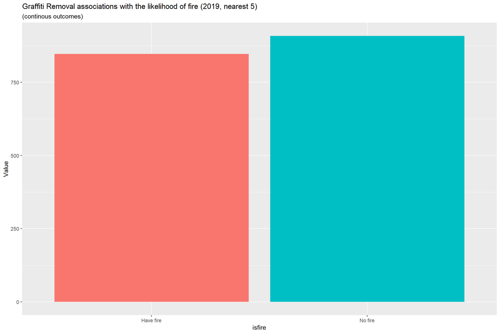

```r
request.sf5    <- request.sf %>% filter(request.sf$service_name == 'Graffiti Removal' )

fire_property_trim$Graffiti.nn5 <-nn_function(st_coordinates(fire_property_trim),st_coordinates(request.sf5),5)

fire_property_trim %>%
    ggplot(aes(isfire, Graffiti.nn5, fill=isfire)) +
      geom_bar(position = "dodge", stat = "summary", fun.y = "mean") +
      #scale_fill_manual(values = palette2) +
      labs(x="isfire", y="Value",
           title = "Graffiti Removal associations with the likelihood of fire (2019, nearest 5)",
           subtitle = "(continous outcomes)") +
      theme(legend.position = "none")
```

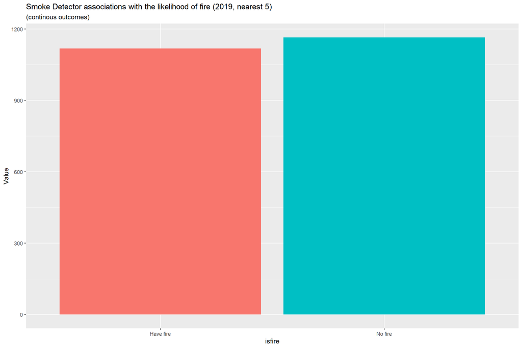

```r
request.sf6    <- request.sf %>% filter(request.sf$service_name == 'Smoke Detector' )

fire_property_trim$Detector.nn5 <-nn_function(st_coordinates(fire_property_trim),st_coordinates(request.sf6),5)

fire_property_trim %>%
    ggplot(aes(isfire, Detector.nn5, fill=isfire)) +
      geom_bar(position = "dodge", stat = "summary", fun.y = "mean") +
      #scale_fill_manual(values = palette2) +
      labs(x="isfire", y="Value",
           title = "Smoke Detector associations with the likelihood of fire (2019, nearest 5)",
           subtitle = "(continous outcomes)") +
      theme(legend.position = "none")
```

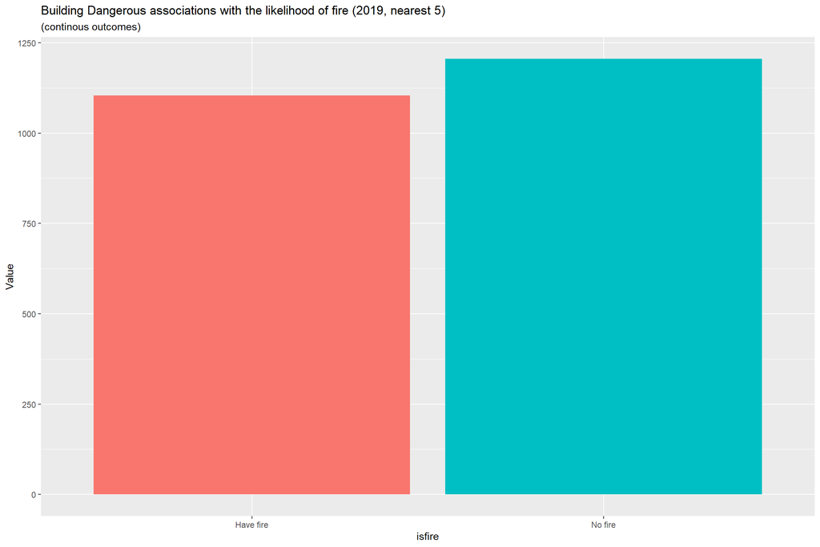

```r
request.sf7    <- request.sf %>% filter(request.sf$service_name == 'Building Dangerous' )

fire_property_trim$Dangerous.nn5 <-nn_function(st_coordinates(fire_property_trim),st_coordinates(request.sf7),5)

fire_property_trim %>%
    ggplot(aes(isfire, Dangerous.nn5, fill=isfire)) +
      geom_bar(position = "dodge", stat = "summary", fun.y = "mean") +
      #scale_fill_manual(values = palette2) +
      labs(x="isfire", y="Value",
           title = "Building Dangerous associations with the likelihood of fire (2019, nearest 5)",
           subtitle = "(continous outcomes)") +
      theme(legend.position = "none")
```

## 0.4 Next Steps

```r
library(tidyverse)
library(httr)

base_url <- "http://api.phila.gov/ais_doc/v1/"
endpoint <- "search/"
address  <- "1234%20market%20st"
key      <- "?gatekeeperKey=6ba4de64d6ca99aa4db3b9194e37adbf"
url <- paste(base_url, endpoint, address, key, sep="")

# response <- httr::GET("http://api.phila.gov/ais_doc/v1/search/1234%20market%20st?gatekeeperKey=6ba4de64d6ca99aa4db3b9194e37adbf")
response <- httr::GET(url)
tidy_res <- httr::content(response, simplifyVector=TRUE)

glimpse(tidy_res$features)
```

```
## Observations: 1
## Variables: 5
## $ type             <chr> "Feature"
## $ ais_feature_type <chr> "address"
## $ match_type       <chr> "exact"
## $ properties       <df[,82]> <data.frame[1 x 82]>
## $ geometry         <df[,3]> <data.frame[1 x 3]>
```

```r
glimpse(tidy_res$features$properties)
```

```
## Observations: 1
## Variables: 82
## $ street_address                  <chr> "1234 MARKET ST"
## $ address_low                     <int> 1234
## $ address_low_suffix              <chr> ""
## $ address_low_frac                <chr> ""
## $ address_high                    <lgl> NA
## $ street_predir                   <chr> ""
## $ street_name                     <chr> "MARKET"
## $ street_suffix                   <chr> "ST"
## $ street_postdir                  <chr> ""
## $ unit_type                       <chr> ""
## $ unit_num                        <chr> ""
## $ street_full                     <chr> "MARKET ST"
## $ street_code                     <int> 53560
```

[output cut: 69 more lines]

```r
glimpse(tidy_res$features$geometry)
```

```
## Observations: 1
## Variables: 3
## $ geocode_type <chr> "pwd_parcel"
## $ type         <chr> "Point"
## $ coordinates  <list> [<-75.16098, 39.95166>]
```